# Explore_bikeshare_data

### Explore Bike Share Data

For this project, your goal is to ask and answer three questions about the available bikeshare data from Washington, Chicago, and New York. This notebook can be submitted directly through the workspace when you are confident in your results.

You will be graded against the project [Rubric](https://review.udacity.com/#!/rubrics/2508/view) by a mentor after you have submitted. To get you started, you can use the template below, but feel free to be creative in your solutions!

```r
ny = read.csv('new_york_city.csv')
wash = read.csv('washington.csv')
chi = read.csv('chicago.csv')
```

# First Steps

The first step will be to create a master file consiting of the three files, a city column will be added to this master data file, and a column for gender for the Washingtan allowing a merge of the 3 files.

```r
head(ny)
```

```r
head(wash)
```

```r
head(chi)
```

```r
# create copies of datafiles

ny_copy = ny
wash_copy = wash
chi_copy = chi
```

```r
# add city column to chi_copy file
chi_copy['City'] = 'Chicago'
# add city column to wash_copy file and column for birth Year and Gender with no value
wash_copy['Gender'] = ''
wash_copy['Birth.Year'] = ''
wash_copy['City'] = 'Washington DC'
# addcity column to ny_copy
ny_copy['City'] = 'New York City'
```

```r
# merge the 3 modified copies into one master
master = rbind(ny_copy, wash_copy, chi_copy)
```

```r
#confirm city value population
table(master$City)
```

```
      Chicago New York City Washington DC
         8630         54770         89051
```

##### Question 1

**What are the top 5 detinations across the 3 cities ranked**

```r
# for clarity's sake add column which is concandenation of city and destination
master$destination = paste(master$City, master$End.Station, sep = ' - ')
```

```r
# prepare data for top 5 destnations
x = table(master$destination)
y = sort(x)
z = tail((y), 5)
top_5 = as.data.frame(z)
```

```r
# inspect top_five
top_5
```

| Var1 | Freq |
| --- | --- |
| Washington DC - Smithsonian-National Mall / Jefferson Dr & 12th St SW | 1103 |
| Washington DC - Massachusetts Ave & Dupont Circle NW | 1344 |
| Washington DC - Lincoln Memorial | 1514 |
| Washington DC - Jefferson Dr & 14th St SW | 1603 |
| Washington DC - Columbus Circle / Union Station | 1767 |

```r
# rename column names in top_five for clarity
colnames(top_5)= c('destination', 'trips')
```

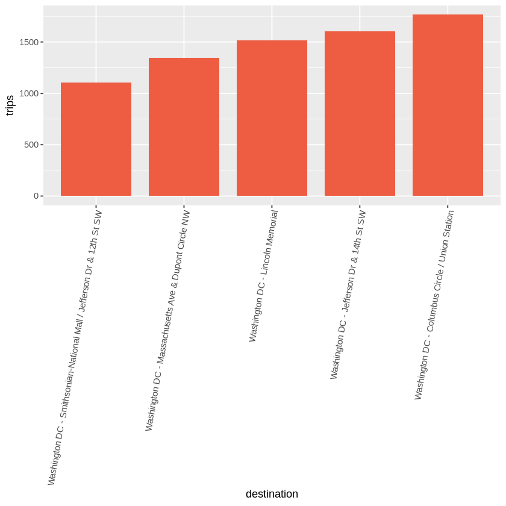

```r
#install libaries for ggplot2
library(ggplot2)

ggplot(top_5,aes(destination, trips)) +
    geom_col(width = 0.8, fill = 'tomato2') +
    theme(axis.text.x = element_text(angle = 80, hjust = 1))
```

**Findings for question 1.***

The top 5 destinations are all located in Wahington DC, this is expected as the Washing file has the most rows of data and this analysis was based on destination resuits.